# Exploratory analysis of emotion similarity networks

Ashish

2021-08-13

In this document, I am conducting exploratory analyses of the recently developed emotion similarity network task. In the task, participants select which two of a set of three emotional images are most similar in their emotional quality. I hypothesize that participants who exhibit self-report characteristics of greater emotional awareness will have more distinct communities in a within person network analysis of each participants’ similarity structure.

# 1 Initialization

```r
rm(list=ls())
library(lmerTest)
library(igraph)
library(kableExtra)
library(here)
library(tidyverse)
theme_set(theme_bw())
```

```r
library(tidylog)
```

# 2 Preprocessing

## 2.1 Functions

```r
#' scale_numerics
#'
#' z-scores values of all numeric columns
#'
#' @param df input dataframe
#' @param new_cols boolean indicating whether to create new columns when scaling or scale in place
#' @param ... arguments to be passed to rsurveyutils::scale()
#'
#' @return dataframe with scaled values
scale_numerics <- function(df, new_cols=TRUE, ...){

  if(new_cols){df %>% mutate_if(is.numeric, list(sc = ~rsurveyutils::scale(., ...)))}
  else {df %>% mutate_if(is.numeric,  ~scale(., ...))}
}
```

## 2.2 Read & process survey data

```r
survey_filepath <- "data/proc/emo_similarity_network_presurvey_sum2021_proc.csv"
df_survey_raw <- read_csv(here(survey_filepath))
df_survey <- df_survey_raw %>%
  group_by(pid) %>%
  # -- remove failed attention checks -- #
  filter((all(ac_paq_pass == 1) & all(ac_pmerq_pass == 1) & all(ac_tas_pass == 1))) %>%
  ungroup
```

## 2.3 Read & process task data

```r
task_filepath <- "data/proc/emoSimilarityTask_proc.csv"

df_task_raw <- read_csv(here(task_filepath))

df_task <- df_task_raw
```

## 2.4 Create data frame of forced choice attention checks

Currently using a .33 minimum threshold of passing attention checks

.33 = 4 correct out of 12, 15% chance of passing threshold if you’re guessing

```r
ac_minimum_threshold <- .33

df_ac_fc <- df_task %>%
  drop_na(ac_forceChoice) %>%
  group_by(pid, pool) %>%
  summarize(pr_correct = mean(ac_forceChoice)) %>%
  ungroup
```

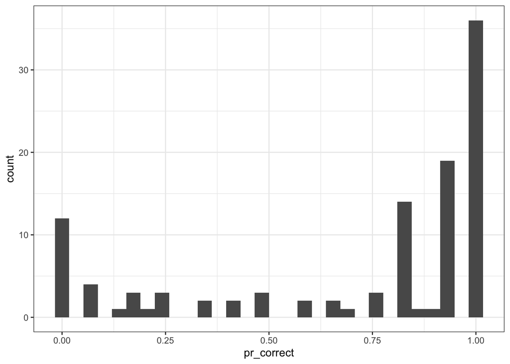

```r
df_ac_fc %>%
  ggplot(aes(x = pr_correct)) +
  geom_histogram()
```

```r
ac_fail_pids <- df_ac_fc %>%
  filter(pr_correct < ac_minimum_threshold) %>%
  pull(pid)

# df_ac_fc %>%
#   filter(pool == "rep" & pr_correct < .33)
```

## 2.5 Create data frame of task trials

```r
df_trials <- df_task %>%
  # -- keep only trials -- #
  filter(trial_type == "image-multi-select") %>%
  filter(!str_detect(img_file_1, "practice_images")) %>%
  # -- remove AC fails -- #
  filter(!pid %in% ac_fail_pids) %>%
  # -- preproc -- #
  select(pid, trial_index, trial_valence,
         img_file_chosen_1, img_file_chosen_2,
         img_file_1, img_file_2, img_file_3) %>%
  pivot_longer(c(img_file_1, img_file_2, img_file_3),
               values_to="img_file", names_to="label") %>%
  mutate(is_chosen=ifelse(img_file == img_file_chosen_1 |
                            img_file == img_file_chosen_2,
                          1, 0)) %>%
  select(-c(img_file_chosen_1, img_file_chosen_2)) %>%
  arrange(pid, trial_index, img_file)

df_trials_wide <- df_trials %>%
  arrange(pid, trial_index, desc(is_chosen), img_file) %>%
  select(-label) %>%
  group_by(pid, trial_index) %>%
  mutate(img_num = 1:n()) %>%
  ungroup %>%
  pivot_wider(id_cols = c(pid, trial_index, trial_valence), names_from = img_num, values_from=c(img_file, is_chosen))
```

# 3 Create graphs community structure and fit clustering

Create clusters using walktrap algorithm

[A Comparative Analysis of Community Detection Algorithms on Artificial Networks](https://www.nature.com/articles/srep30750.pdf)

```r
get_graph <- function(df){
   df %>%
    select(img_file_1, img_file_2) %>%
    graph_from_data_frame(directed=FALSE)
}

df_graphs <- df_trials_wide %>%
  group_by(pid, trial_valence) %>%
  nest() %>%
  mutate(graph = map(data, get_graph)) %>%
  mutate(cluster = map(graph, cluster_walktrap)) %>%
  mutate(modularity = map_dbl(cluster, modularity)) %>%
  # mutate(cluster_plot = map2(cluster, graph, ~plot(.x, .y))) %>%
  mutate(n_clusters = map_dbl(cluster, ~length(unique(.$membership))))
```

[output not shown]

# 4 Sample characteristics

## 4.1 Number of rows per participant

```r
df_task %>%
  group_by(pid) %>%
  summarise(n = n()) %>%
  arrange(n) %>%
  kbl %>%
  kable_styling %>%
  scroll_box(height="500px", width = "300px")
```

| pid | n |
| --- | --- |
| 94165 | 1 |
| 9999 | 3 |
| 96121 | 35 |
| 96076 | 36 |
| 96919 | 89 |
| 96790 | 90 |
| 6666 | 93 |
| 96427 | 95 |
| 96502 | 143 |
| 6591 | 347 |
| 6593 | 347 |
| 6596 | 347 |
| 6597 | 347 |
| 6598 | 347 |
| 6600 | 347 |
| 6605 | 347 |
| 6606 | 347 |
| 6609 | 347 |
| 6623 | 347 |
| 6631 | 347 |
| 6636 | 347 |
| 6639 | 347 |
| 6652 | 347 |
| 6655 | 347 |
| 6657 | 347 |
| 6658 | 347 |
| 6662 | 347 |
| 6676 | 347 |
| 6679 | 347 |
| 6687 | 347 |

[output cut: 82 more lines]

```r
df_task %>% pull(pid) %>% unique
```

```
##   [1] 96301  6687  6658 96274 96838  6719 96073 96070 96829 96064  6652 96934
##  [13] 96307 96001  6598 79336 96286  6720  6623 96265 96295 96229  6662  6702
##  [25]  6700  6597 96190 96628 96022 96055  6721  6655  6596  6618  6639  6600
##  [37]  6593  6689  6676  6679  6657  6659 96796 96394 96655 96874 96961 96973
##  [49]  6604 96637 96925 96712  6737 94204 92725 96886 96409 96850 94918 96691
##  [61] 96415 96871 96736 96547  6697  6704  6606 96268 96937 93568  6648 96823
##  [73] 96805 95320 96382 94876 96484 96697  6631  6605  6636 96130 96109 94570
##  [85] 96679 96124 91741 96517 96385 96016 96172 96256 91174 96136 96940 96634
##  [97] 96370 96013 96244  6591  6609 96292 96526  9999 96790 96502 94165 96919
## [109]  6666 96121 96076 96427
```

## 4.2 Response time distribution

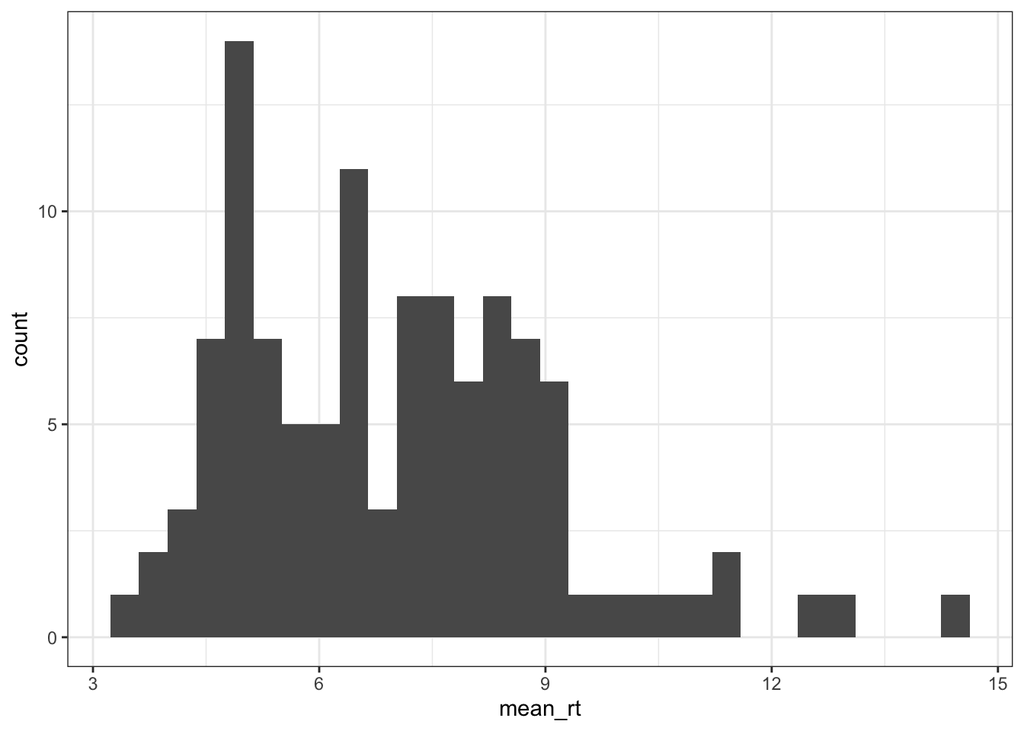

```r
# participant mean response time
df_task %>%
  mutate(rt = as.numeric(rt)/1000) %>%
  filter(rsurveyutils::scale(rt) < 3) %>% # remove outliers if 3 SDs above mean
  group_by(pid) %>%
  summarize(mean_rt = mean(rt)) %>%
  ggplot(aes(x = mean_rt)) +
  geom_histogram()
```

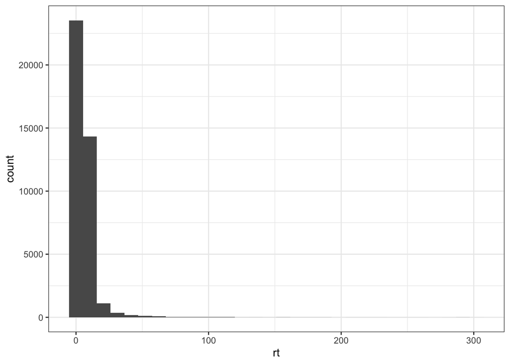

```r
# trial response time
df_task %>%
  mutate(rt = as.numeric(rt)/1000) %>%
  filter(rsurveyutils::scale(rt) < 3) %>% # remove if 3 SDs above mean
  ggplot(aes(x = rt)) +
  geom_histogram()
```

## 4.3 Plot total time spent on survey

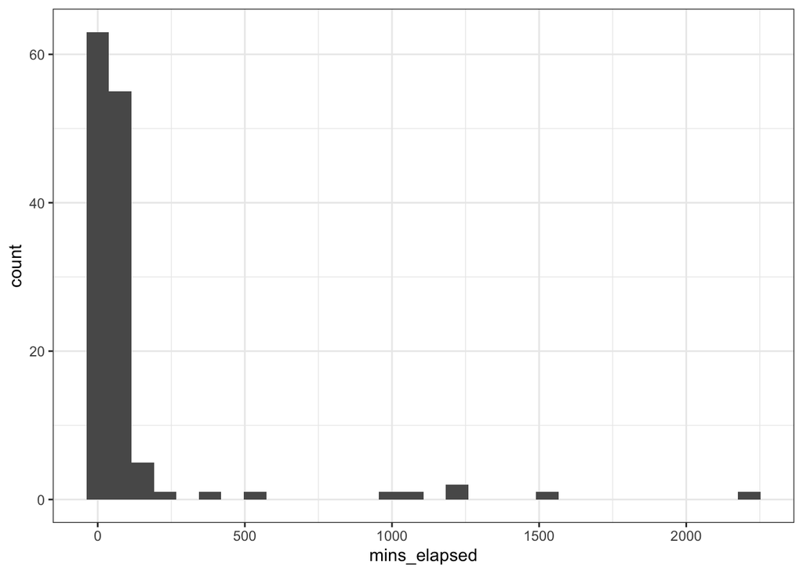

```r
df_task %>%
  group_by(run_id) %>%
  filter(time_elapsed == max(time_elapsed)) %>%
  ungroup %>%
  mutate(mins_elapsed = as.numeric(time_elapsed)/(1000*60)) %>%
  ggplot(aes(x = mins_elapsed)) +
  geom_histogram()
```

# 5 Plot all participant networks and clusters and export to PDF

I’m also including their PAQ score and their responses to the attention checks in the within person network PDFs.

```r
clusterPlots_dir <- here(paste0("results/", Sys.Date(), "/clusterPlots"))
dir.create(clusterPlots_dir, recursive=TRUE)
pdf(paste0(clusterPlots_dir, "/pid_valence_clusterPlots.pdf"))
for(i in 1:nrow(df_graphs)){
  # plot of clusters
  plot(df_graphs$cluster[[i]],
       df_graphs$graph[[i]],
       main=paste(df_graphs$pid[i], df_graphs$trial_valence[i]))
  # get free response dimensions of clustering
  freeResp <- df_task %>%
    filter(pid == df_graphs$pid[[i]]) %>%
    filter(ac_freeResp != "") %>%
    filter(trial_valence == df_graphs$trial_valence[[i]]) %>%
    pull(ac_freeResp)
  if(length(freeResp) > 0){
    text(0,-1.4, labels=paste(freeResp, collapse = "\n"))
  }
  # get attention check score
  pr_correct <- df_ac_fc %>%
    filter(pid == df_graphs$pid[[i]]) %>%
    pull(pr_correct)
  text(-1.2,1.3, labels=paste("AC correct pr:", round(pr_correct, 2)))
  # get PAQ score
  paq_score <- df_survey %>%
    mutate(paq = rsurveyutils::scale(paq)) %>%
    filter(pid == df_graphs$pid[[i]]) %>%
    pull(paq)
    text(-1.2,seq(1.1, by = -.1, length.out = length(paq_score)),
         labels=paste("PAQ:", round(paq_score, 2)))

}
dev.off()
```

# 6 Differences by trial valence

Here I’m exploring whether network metrics are different depending on what valence type of block the participant was in

## 6.1 Modularity metric per trial valence

Modularity metric

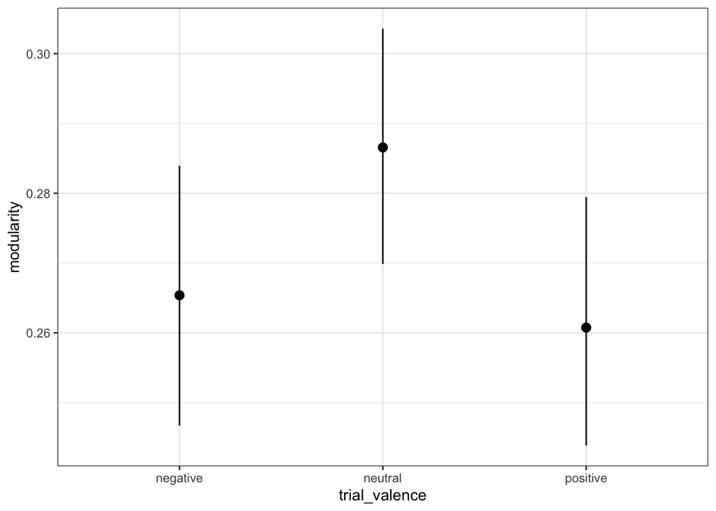

```r
df_graphs %>%
  ggplot(aes(y = modularity, x = trial_valence)) +
  # geom_point(alpha = .3, position=position_jitter(.1)) +
  stat_summary(fun.data = "mean_cl_boot")
```

```r
df_graphs %>%
  lmer(modularity ~ (1|pid), .) %>%
  summary
```

```
## Linear mixed model fit by REML. t-tests use Satterthwaite's method [
## lmerModLmerTest]
## Formula: modularity ~ (1 | pid)
##    Data: .
##
## REML criterion at convergence: -558.7
##
## Scaled residuals:
##     Min      1Q  Median      3Q     Max
## -2.7403 -0.5522 -0.0406  0.5011  3.3032
##
## Random effects:
##  Groups   Name        Variance Std.Dev.
##  pid      (Intercept) 0.003661 0.06050
##  Residual             0.003878 0.06227
## Number of obs: 250, groups:  pid, 86
##
## Fixed effects:
##             Estimate Std. Error       df t value Pr(>|t|)
## (Intercept)  0.27443    0.00764 73.82096   35.92   <2e-16 ***
## ---
## Signif. codes:  0 '***' 0.001 '**' 0.01 '*' 0.05 '.' 0.1 ' ' 1
```

```r
df_graphs %>%
  lmer(modularity ~ trial_valence + (1|pid), .) %>%
  summary
```

```
## Linear mixed model fit by REML. t-tests use Satterthwaite's method [
## lmerModLmerTest]
## Formula: modularity ~ trial_valence + (1 | pid)
##    Data: .
##
## REML criterion at convergence: -556.2
##
## Scaled residuals:
##     Min      1Q  Median      3Q     Max
## -2.6027 -0.5498 -0.0667  0.4437  3.4679
##
## Random effects:
##  Groups   Name        Variance Std.Dev.
##  pid      (Intercept) 0.004000 0.06324
##  Residual             0.003548 0.05957
## Number of obs: 250, groups:  pid, 86
##
## Fixed effects:
##                         Estimate Std. Error         df t value Pr(>|t|)
## (Intercept)             0.268507   0.009443 151.097528  28.433  < 2e-16 ***
## trial_valenceneutral    0.026124   0.009330 152.379864   2.800  0.00577 **
## trial_valencepositive  -0.006234   0.009203 152.167536  -0.677  0.49914
## ---
## Signif. codes:  0 '***' 0.001 '**' 0.01 '*' 0.05 '.' 0.1 ' ' 1
##
## Correlation of Fixed Effects:
##             (Intr) trl_vlncn
## trl_vlncntr -0.482
## trl_vlncpst -0.491  0.497
```

## 6.2 Mean clusters per trial valence

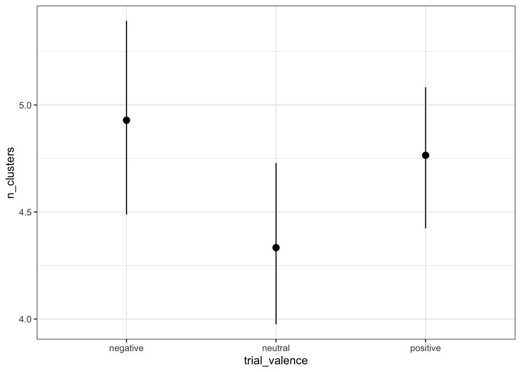

```r
df_graphs %>%
  ggplot(aes(y = n_clusters, x = trial_valence)) +
  # geom_point(alpha = .3, position=position_jitter(.1)) +
  stat_summary(fun.data = "mean_cl_boot")
```

```r
df_graphs %>%
  lmer(n_clusters ~ (1|pid), .) %>%
  summary
```

```
## Linear mixed model fit by REML. t-tests use Satterthwaite's method [
## lmerModLmerTest]
## Formula: n_clusters ~ (1 | pid)
##    Data: .
##
## REML criterion at convergence: 1010.4
##
## Scaled residuals:
##     Min      1Q  Median      3Q     Max
## -1.6152 -0.7248 -0.1663  0.4157  4.9705
##
## Random effects:
##  Groups   Name        Variance Std.Dev.
##  pid      (Intercept) 0.4089   0.6395
##  Residual             2.9519   1.7181
## Number of obs: 250, groups:  pid, 86
##
## Fixed effects:
##             Estimate Std. Error      df t value Pr(>|t|)
## (Intercept)   4.6816     0.1289 85.6778   36.31   <2e-16 ***
## ---
## Signif. codes:  0 '***' 0.001 '**' 0.01 '*' 0.05 '.' 0.1 ' ' 1
```

```r
df_graphs %>%
  lmer(n_clusters ~ trial_valence + (1|pid), .) %>%
  summary
```

```
## Linear mixed model fit by REML. t-tests use Satterthwaite's method [
## lmerModLmerTest]
## Formula: n_clusters ~ trial_valence + (1 | pid)
##    Data: .
##
## REML criterion at convergence: 1006.9
##
## Scaled residuals:
##     Min      1Q  Median      3Q     Max
## -1.7858 -0.6674 -0.0766  0.4461  4.8489
##
## Random effects:
##  Groups   Name        Variance Std.Dev.
##  pid      (Intercept) 0.4339   0.6587
##  Residual             2.8880   1.6994
## Number of obs: 250, groups:  pid, 86
##
## Fixed effects:
##                       Estimate Std. Error       df t value Pr(>|t|)
## (Intercept)             4.9343     0.1988 239.7649  24.819   <2e-16 ***
## trial_valenceneutral   -0.6022     0.2651 167.3871  -2.272   0.0244 *
## trial_valencepositive  -0.1710     0.2617 166.3581  -0.653   0.5144
## ---
## Signif. codes:  0 '***' 0.001 '**' 0.01 '*' 0.05 '.' 0.1 ' ' 1
##
## Correlation of Fixed Effects:
##             (Intr) trl_vlncn
## trl_vlncntr -0.653
## trl_vlncpst -0.663  0.497
```

# 7 Relationship between modularity metric and number of clusters metric

```r
cor.test(df_graphs$modularity, df_graphs$n_clusters)
```

```
##
##  Pearson's product-moment correlation
##
## data:  df_graphs$modularity and df_graphs$n_clusters
## t = -5.5957, df = 248, p-value = 5.801e-08
## alternative hypothesis: true correlation is not equal to 0
## 95 percent confidence interval:
##  -0.4405860 -0.2198882
## sample estimates:
##       cor
## -0.334821
```

# 8 Relation of modularity to alexithymia

Here and in the valence analysis, the modularity metric is not behaving as expected. I have not continued with modularity analyses beyond the full scale of alexithymia for this reason.

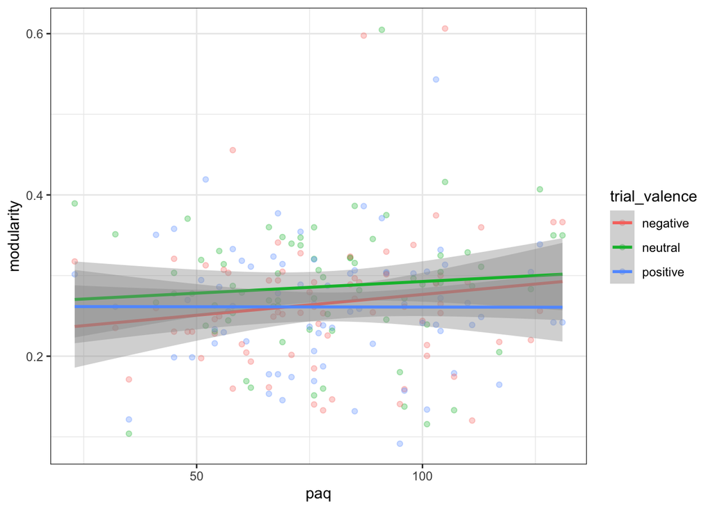

```r
dat <- df_survey %>%
  select(pid, paq) %>%
  inner_join(df_graphs)
dat %>%
  ggplot(aes(x = paq, y = modularity, color = trial_valence)) +
  geom_point(alpha = .3) +
  geom_smooth(method="lm")
```

```r
# dat %>%
#   lmer(modularity ~ paq + (1|pid), .) %>%
#   summary
```

# 9 Relation of n clusters to variables

## 9.1 Alexithymia

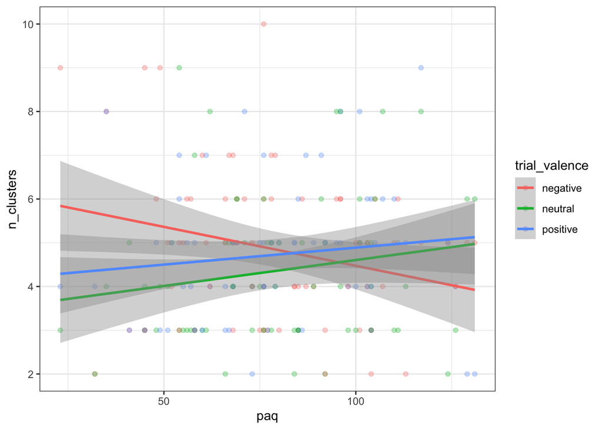

```r
dat <- df_survey %>%
  select(pid, matches("paq(.*[^0-9]$|$)")) %>%
  inner_join(df_graphs)
## Full scale
dat %>%
  ggplot(aes(x = paq, y = n_clusters, color = trial_valence)) +
  geom_point(alpha = .3) +
  geom_smooth(method="lm")
```

```r
dat %>%
  filter(trial_valence == "negative") %>%
  mutate_if(is.numeric, scale) %>%
  lm(n_clusters ~ paq, .) %>%
  summary
```

```
##
## Call:
## lm(formula = n_clusters ~ paq, data = .)
##
## Residuals:
##      Min       1Q   Median       3Q      Max
## -2.07648 -0.79078 -0.03402  0.61073  2.87547
##
## Coefficients:
##               Estimate Std. Error t value Pr(>|t|)
## (Intercept)  7.599e-18  1.151e-01   0.000   1.0000
## paq         -2.442e-01  1.159e-01  -2.107   0.0387 *
## ---
## Signif. codes:  0 '***' 0.001 '**' 0.01 '*' 0.05 '.' 0.1 ' ' 1
##
## Residual standard error: 0.9766 on 70 degrees of freedom
## Multiple R-squared:  0.05965,    Adjusted R-squared:  0.04621
## F-statistic:  4.44 on 1 and 70 DF,  p-value: 0.03869
```

```r
dat %>%
  filter(trial_valence == "neutral") %>%
  mutate_if(is.numeric, scale) %>%
  lm(n_clusters ~ paq, .) %>%
  summary
```

```
##
## Call:
## lm(formula = n_clusters ~ paq, data = .)
##
## Residuals:
##     Min      1Q  Median      3Q     Max
## -1.7345 -0.7285 -0.1708  0.4758  2.9663
##
## Coefficients:
##               Estimate Std. Error t value Pr(>|t|)
## (Intercept) -4.115e-17  1.177e-01   0.000    1.000
## paq          1.735e-01  1.186e-01   1.464    0.148
##
## Residual standard error: 0.9919 on 69 degrees of freedom
## Multiple R-squared:  0.03011,    Adjusted R-squared:  0.01606
## F-statistic: 2.142 on 1 and 69 DF,  p-value: 0.1478
```

```r
dat %>%
  filter(trial_valence == "positive") %>%
  mutate_if(is.numeric, scale) %>%
  lm(n_clusters ~ paq, .) %>%
  summary
```

```
##
## Call:
## lm(formula = n_clusters ~ paq, data = .)
##
## Residuals:
##      Min       1Q   Median       3Q      Max
## -2.04480 -0.59552  0.04798  0.29649  2.60169
##
## Coefficients:
##              Estimate Std. Error t value Pr(>|t|)
## (Intercept) 1.661e-16  1.170e-01   0.000      1.0
## paq         1.229e-01  1.178e-01   1.043      0.3
##
## Residual standard error: 0.9994 on 71 degrees of freedom
## Multiple R-squared:  0.0151, Adjusted R-squared:  0.001231
## F-statistic: 1.089 on 1 and 71 DF,  p-value: 0.3003
```

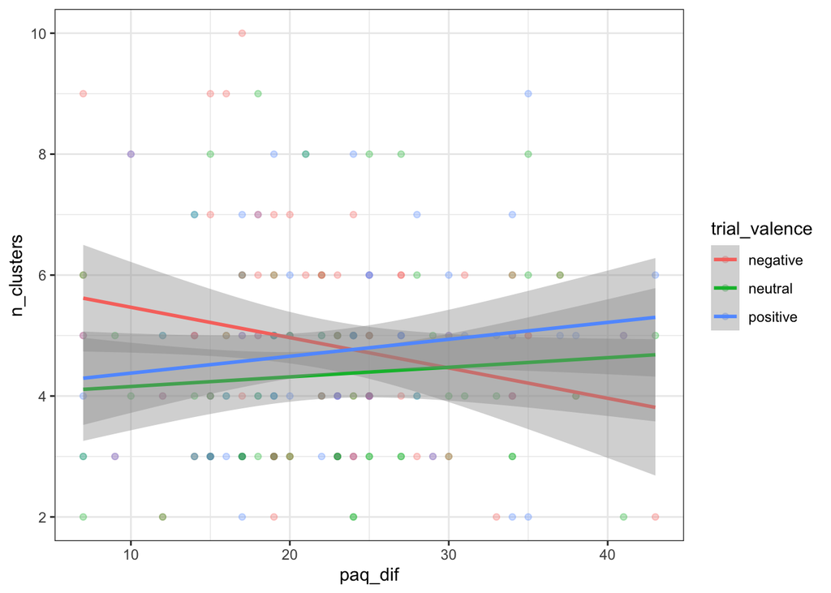

```r
## DIF

dat %>%
  ggplot(aes(x = paq_dif, y = n_clusters, color = trial_valence)) +
  geom_point(alpha = .3) +
  geom_smooth(method="lm")
```

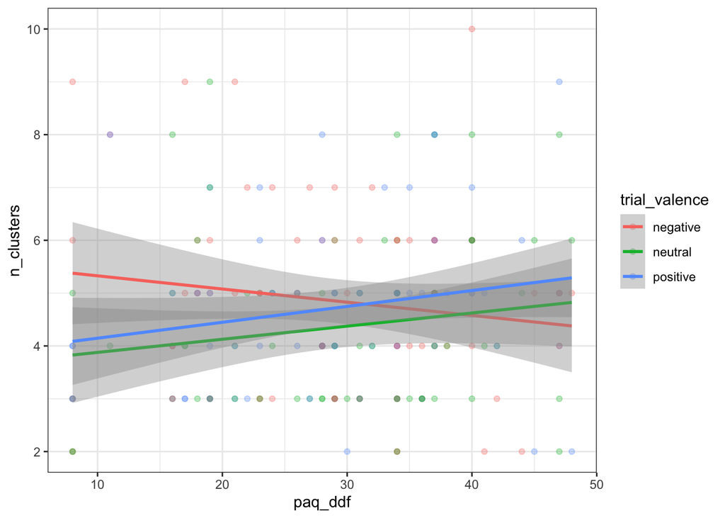

```r
# DDF
dat %>%
  ggplot(aes(x = paq_ddf, y = n_clusters, color = trial_valence)) +
  geom_point(alpha = .3) +
  geom_smooth(method="lm")
```

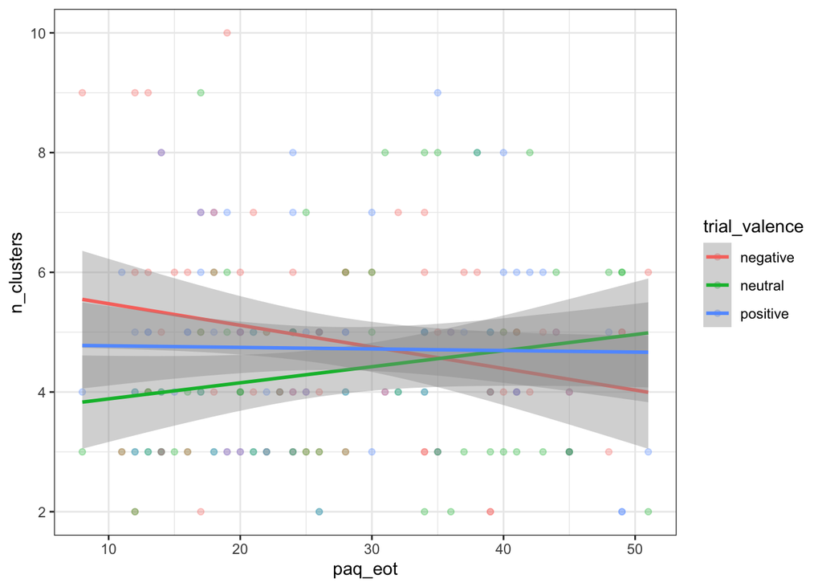

```r
## EOT
dat %>%
  ggplot(aes(x = paq_eot, y = n_clusters, color = trial_valence)) +
  geom_point(alpha = .3) +
  geom_smooth(method="lm")
```

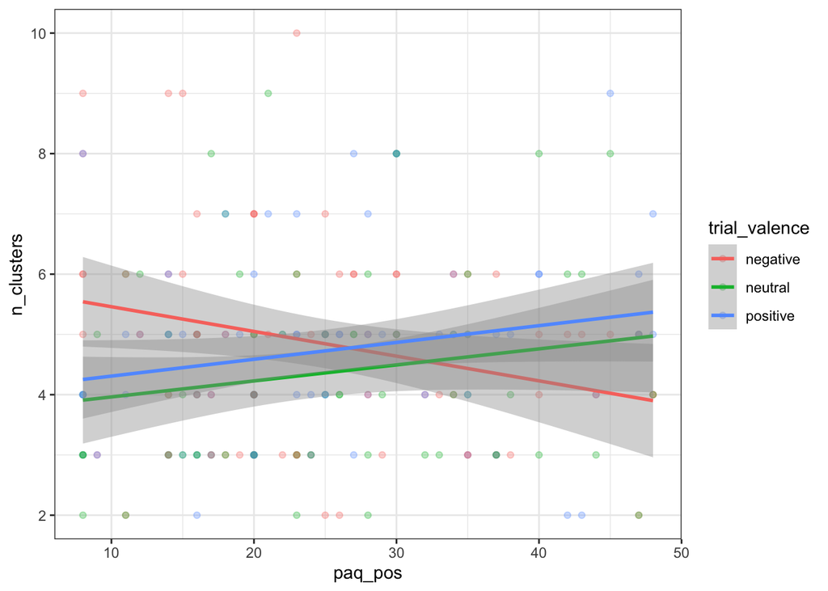

```r
## PAQ Pos
dat %>%
  ggplot(aes(x = paq_pos, y = n_clusters, color = trial_valence)) +
  geom_point(alpha = .3) +
  geom_smooth(method="lm")
```

```r
dat %>%
  filter(trial_valence == "negative") %>%
  mutate_if(is.numeric, scale) %>%
  lm(n_clusters ~ paq_pos, .) %>%
  summary
```

```
##
## Call:
## lm(formula = n_clusters ~ paq_pos, data = .)
##
## Residuals:
##      Min       1Q   Median       3Q      Max
## -1.92745 -0.74521 -0.01628  0.62271  2.86078
##
## Coefficients:
##               Estimate Std. Error t value Pr(>|t|)
## (Intercept)  4.562e-17  1.147e-01   0.000   1.0000
## paq_pos     -2.566e-01  1.155e-01  -2.222   0.0295 *
## ---
## Signif. codes:  0 '***' 0.001 '**' 0.01 '*' 0.05 '.' 0.1 ' ' 1
##
## Residual standard error: 0.9734 on 70 degrees of freedom
## Multiple R-squared:  0.06586,    Adjusted R-squared:  0.05252
## F-statistic: 4.936 on 1 and 70 DF,  p-value: 0.02954
```

```r
dat %>%
  filter(trial_valence == "neutral") %>%
  mutate_if(is.numeric, scale) %>%
  lm(n_clusters ~ paq_pos, .) %>%
  summary
```

```
##
## Call:
## lm(formula = n_clusters ~ paq_pos, data = .)
##
## Residuals:
##     Min      1Q  Median      3Q     Max
## -1.7685 -0.7215 -0.2168  0.4953  2.8489
##
## Coefficients:
##              Estimate Std. Error t value Pr(>|t|)
## (Intercept) 1.595e-17  1.177e-01   0.000    1.000
## paq_pos     1.729e-01  1.186e-01   1.458    0.149
##
## Residual standard error: 0.9921 on 69 degrees of freedom
## Multiple R-squared:  0.02989,    Adjusted R-squared:  0.01583
## F-statistic: 2.126 on 1 and 69 DF,  p-value: 0.1494
```

```r
dat %>%
  filter(trial_valence == "positive") %>%
  mutate_if(is.numeric, scale) %>%
  lm(n_clusters ~ paq_pos, .) %>%
  summary
```

```
##
## Call:
## lm(formula = n_clusters ~ paq_pos, data = .)
##
## Residuals:
##     Min      1Q  Median      3Q     Max
## -2.1107 -0.6027 -0.0403  0.3792  2.4496
##
## Coefficients:
##              Estimate Std. Error t value Pr(>|t|)
## (Intercept) 2.204e-16  1.155e-01   0.000   1.0000
## paq_pos     2.012e-01  1.163e-01   1.731   0.0879 .
## ---
## Signif. codes:  0 '***' 0.001 '**' 0.01 '*' 0.05 '.' 0.1 ' ' 1
##
## Residual standard error: 0.9864 on 71 degrees of freedom
## Multiple R-squared:  0.04048,    Adjusted R-squared:  0.02696
## F-statistic: 2.995 on 1 and 71 DF,  p-value: 0.08785
```

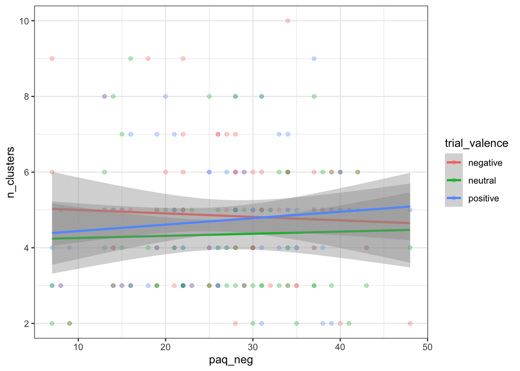

```r
## PAQ Neg
dat %>%
  ggplot(aes(x = paq_neg, y = n_clusters, color = trial_valence)) +
  geom_point(alpha = .3) +
  geom_smooth(method="lm")
```

```r
dat %>%
  filter(trial_valence == "negative") %>%
  mutate_if(is.numeric, scale) %>%
  lm(n_clusters ~ paq_neg, .) %>%
  summary
```

```
##
## Call:
## lm(formula = n_clusters ~ paq_neg, data = .)
##
## Residuals:
##      Min       1Q   Median       3Q      Max
## -1.69711 -0.99820  0.05159  0.66349  2.94357
##
## Coefficients:
##               Estimate Std. Error t value Pr(>|t|)
## (Intercept)  4.914e-17  1.185e-01   0.000    1.000
## paq_neg     -4.884e-02  1.194e-01  -0.409    0.684
##
## Residual standard error: 1.006 on 70 degrees of freedom
## Multiple R-squared:  0.002385,   Adjusted R-squared:  -0.01187
## F-statistic: 0.1674 on 1 and 70 DF,  p-value: 0.6837
```

```r
dat %>%
  filter(trial_valence == "neutral") %>%
  mutate_if(is.numeric, scale) %>%
  lm(n_clusters ~ paq_neg, .) %>%
  summary
```

```
##
## Call:
## lm(formula = n_clusters ~ paq_neg, data = .)
##
## Residuals:
##     Min      1Q  Median      3Q     Max
## -1.4603 -0.8079 -0.2092  0.4097  2.8263
##
## Coefficients:
##              Estimate Std. Error t value Pr(>|t|)
## (Intercept) 2.076e-18  1.195e-01   0.000    1.000
## paq_neg     3.151e-02  1.203e-01   0.262    0.794
##
## Residual standard error: 1.007 on 69 degrees of freedom
## Multiple R-squared:  0.0009928,  Adjusted R-squared:  -0.01349
## F-statistic: 0.06857 on 1 and 69 DF,  p-value: 0.7942
```

```r
dat %>%
  filter(trial_valence == "positive") %>%
  mutate_if(is.numeric, scale) %>%
  lm(n_clusters ~ paq_neg, .) %>%
  summary
```

```
##
## Call:
## lm(formula = n_clusters ~ paq_neg, data = .)
##
## Residuals:
##      Min       1Q   Median       3Q      Max
## -1.91862 -0.58902  0.03115  0.31004  2.67919
##
## Coefficients:
##              Estimate Std. Error t value Pr(>|t|)
## (Intercept) 1.985e-16  1.172e-01   0.000    1.000
## paq_neg     1.045e-01  1.180e-01   0.885    0.379
##
## Residual standard error: 1.002 on 71 degrees of freedom
## Multiple R-squared:  0.01092,    Adjusted R-squared:  -0.003014
## F-statistic: 0.7836 on 1 and 71 DF,  p-value: 0.379
```

## 9.2 ERQ Reappraisal

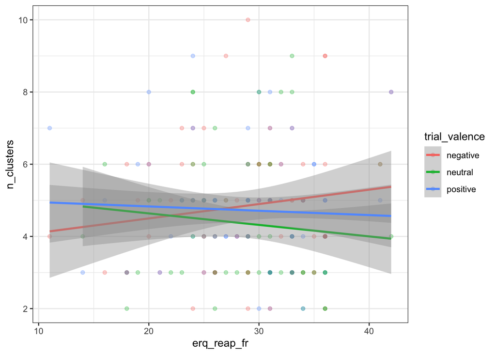

```r
dat <- df_survey %>%
  select(pid, matches("^erq(.*[^0-9]$|$)")) %>%
  inner_join(df_graphs)
dat %>%
  ggplot(aes(x = erq_reap_fr, y = n_clusters, color = trial_valence)) +
  geom_point(alpha = .3) +
  geom_smooth(method="lm")
```

```r
dat %>%
  filter(trial_valence == "negative" ) %>%
  mutate_if(is.numeric, scale) %>%
  lm(n_clusters ~ erq_reap_fr, . ) %>%
  summary
```

```
##
## Call:
## lm(formula = n_clusters ~ erq_reap_fr, data = .)
##
## Residuals:
##      Min       1Q   Median       3Q      Max
## -1.76776 -0.76641  0.01354  0.60544  2.90011
##
## Coefficients:
##              Estimate Std. Error t value Pr(>|t|)
## (Intercept) 5.547e-17  1.176e-01   0.000    1.000
## erq_reap_fr 1.370e-01  1.184e-01   1.157    0.251
##
## Residual standard error: 0.9976 on 70 degrees of freedom
## Multiple R-squared:  0.01878,    Adjusted R-squared:  0.004763
## F-statistic:  1.34 on 1 and 70 DF,  p-value: 0.251
```

```r
dat %>%
  filter(trial_valence == "negative" | trial_valence == "neutral") %>%
  mutate_if(is.numeric, scale) %>%
  lm(n_clusters ~ erq_reap_fr*trial_valence, . ) %>%
  summary
```

```
##
## Call:
## lm(formula = n_clusters ~ erq_reap_fr * trial_valence, data = .)
##
## Residuals:
##      Min       1Q   Median       3Q      Max
## -1.80948 -0.74284 -0.07376  0.56806  2.96856
##
## Coefficients:
##                                  Estimate Std. Error t value Pr(>|t|)
## (Intercept)                        0.1441     0.1170   1.232   0.2201
## erq_reap_fr                        0.1363     0.1145   1.191   0.2357
## trial_valenceneutral              -0.2862     0.1660  -1.724   0.0869 .
## erq_reap_fr:trial_valenceneutral  -0.2454     0.1669  -1.471   0.1436
## ---
## Signif. codes:  0 '***' 0.001 '**' 0.01 '*' 0.05 '.' 0.1 ' ' 1
##
## Residual standard error: 0.9924 on 139 degrees of freedom
## Multiple R-squared:  0.036,  Adjusted R-squared:  0.01519
## F-statistic:  1.73 on 3 and 139 DF,  p-value: 0.1636
```

## 9.3 ERQ suppression

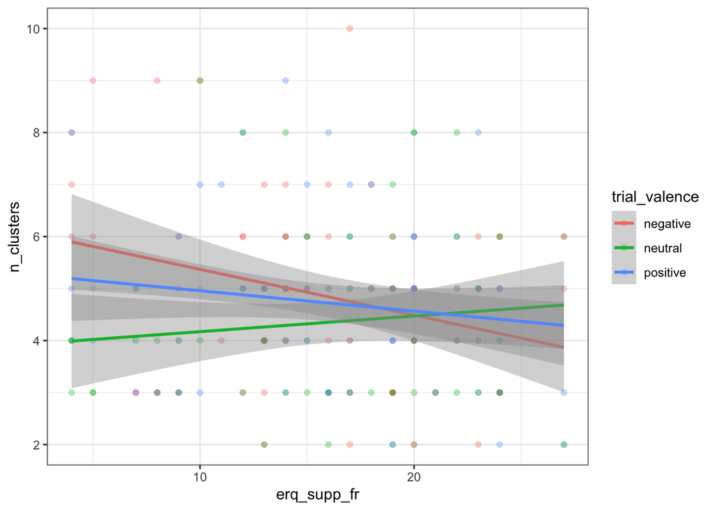

```r
dat <- df_survey %>%
  select(pid, matches("^erq(.*[^0-9]$|$)")) %>%
  inner_join(df_graphs)
dat %>%
  ggplot(aes(x = erq_supp_fr, y = n_clusters, color = trial_valence)) +
  geom_point(alpha = .3) +
  geom_smooth(method="lm")
```

```r
dat %>%
  filter(trial_valence == "negative" ) %>%
  mutate_if(is.numeric, scale) %>%
  lm(n_clusters ~ erq_supp_fr, . ) %>%
  summary
```

```
##
## Call:
## lm(formula = n_clusters ~ erq_supp_fr, data = .)
##
## Residuals:
##      Min       1Q   Median       3Q      Max
## -1.75101 -0.64065  0.01507  0.56650  2.95854
##
## Coefficients:
##               Estimate Std. Error t value Pr(>|t|)
## (Intercept)  7.508e-17  1.136e-01   0.000   1.0000
## erq_supp_fr -2.897e-01  1.144e-01  -2.533   0.0136 *
## ---
## Signif. codes:  0 '***' 0.001 '**' 0.01 '*' 0.05 '.' 0.1 ' ' 1
##
## Residual standard error: 0.9639 on 70 degrees of freedom
## Multiple R-squared:  0.08395,    Adjusted R-squared:  0.07086
## F-statistic: 6.415 on 1 and 70 DF,  p-value: 0.01356
```

```r
dat %>%
  filter(trial_valence == "negative" | trial_valence == "neutral") %>%
  mutate_if(is.numeric, scale) %>%
  lm(n_clusters ~ erq_supp_fr*trial_valence, . ) %>%
  summary
```

```
##
## Call:
## lm(formula = n_clusters ~ erq_supp_fr * trial_valence, data = .)
##
## Residuals:
##      Min       1Q   Median       3Q      Max
## -1.79234 -0.75431 -0.08151  0.51449  3.02837
##
## Coefficients:
##                                  Estimate Std. Error t value Pr(>|t|)
## (Intercept)                        0.1401     0.1149   1.220   0.2247
## erq_supp_fr                       -0.2958     0.1154  -2.563   0.0114 *
## trial_valenceneutral              -0.2846     0.1631  -1.745   0.0831 .
## erq_supp_fr:trial_valenceneutral   0.3970     0.1636   2.426   0.0165 *
## ---
## Signif. codes:  0 '***' 0.001 '**' 0.01 '*' 0.05 '.' 0.1 ' ' 1
##
## Residual standard error: 0.9749 on 139 degrees of freedom
## Multiple R-squared:  0.06962,    Adjusted R-squared:  0.04954
## F-statistic: 3.467 on 3 and 139 DF,  p-value: 0.01801
```

## 9.4 PHQ

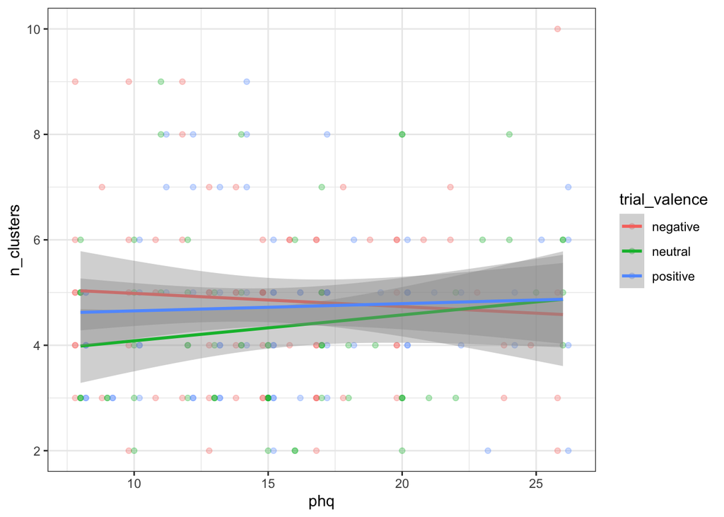

```r
dat <- df_survey %>%
  select(pid, matches("^phq(.*[^0-9]$|$)"), -matches("timer")) %>%
  inner_join(df_graphs)
dat %>%
  ggplot(aes(x = phq, y = n_clusters, color = trial_valence)) +
  geom_point(alpha = .3, position = position_dodge(.6)) +
  geom_smooth(method="lm")
```

```r
dat %>%
  filter(trial_valence == "negative" ) %>%
  mutate_if(is.numeric, scale) %>%
  lm(n_clusters ~ phq, . ) %>%
  summary
```

```
##
## Call:
## lm(formula = n_clusters ~ phq, data = .)
##
## Residuals:
##      Min       1Q   Median       3Q      Max
## -1.68228 -0.89961  0.03752  0.65784  3.05442
##
## Coefficients:
##               Estimate Std. Error t value Pr(>|t|)
## (Intercept)  6.164e-17  1.184e-01   0.000    1.000
## phq         -7.112e-02  1.192e-01  -0.597    0.553
##
## Residual standard error: 1.005 on 70 degrees of freedom
## Multiple R-squared:  0.005058,   Adjusted R-squared:  -0.009156
## F-statistic: 0.3558 on 1 and 70 DF,  p-value: 0.5528
```

```r
dat %>%
  filter(trial_valence == "negative" | trial_valence == "neutral") %>%
  mutate_if(is.numeric, scale) %>%
  lm(n_clusters ~ phq*trial_valence, . ) %>%
  summary
```

```
##
## Call:
## lm(formula = n_clusters ~ phq * trial_valence, data = .)
##
## Residuals:
##     Min      1Q  Median      3Q     Max
## -1.7220 -0.7676 -0.1053  0.6083  3.1265
##
## Coefficients:
##                          Estimate Std. Error t value Pr(>|t|)
## (Intercept)               0.14183    0.11711   1.211   0.2279
## phq                      -0.07283    0.11799  -0.617   0.5381
## trial_valenceneutral     -0.28580    0.16620  -1.720   0.0877 .
## phq:trial_valenceneutral  0.21579    0.16678   1.294   0.1978
## ---
## Signif. codes:  0 '***' 0.001 '**' 0.01 '*' 0.05 '.' 0.1 ' ' 1
##
## Residual standard error: 0.9937 on 139 degrees of freedom
## Multiple R-squared:  0.03344,    Adjusted R-squared:  0.01258
## F-statistic: 1.603 on 3 and 139 DF,  p-value: 0.1915
```

## 9.5 GAD

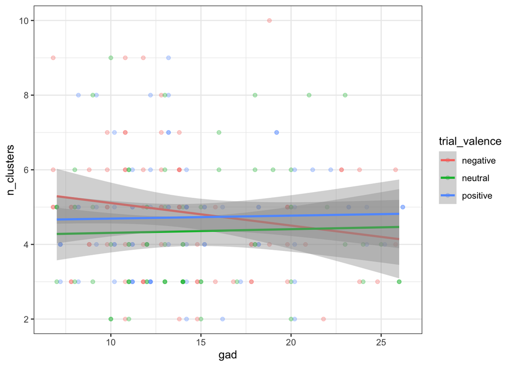

```r
dat <- df_survey %>%
  select(pid, matches("^gad(.*[^0-9]$|$)"), -matches("timer")) %>%
  inner_join(df_graphs)
dat %>%
  ggplot(aes(x = gad, y = n_clusters, color = trial_valence)) +
  geom_point(alpha = .3, position = position_dodge(.6)) +
  geom_smooth(method="lm")
```

```r
dat %>%
  filter(trial_valence == "negative" ) %>%
  mutate_if(is.numeric, scale) %>%
  lm(n_clusters ~ gad, . ) %>%
  summary
```

```
##
## Call:
## lm(formula = n_clusters ~ gad, data = .)
##
## Residuals:
##     Min      1Q  Median      3Q     Max
## -1.7190 -0.6865 -0.0708  0.5790  3.0645
##
## Coefficients:
##               Estimate Std. Error t value Pr(>|t|)
## (Intercept)  2.685e-17  1.169e-01   0.000     1.00
## gad         -1.712e-01  1.178e-01  -1.454     0.15
##
## Residual standard error: 0.9922 on 70 degrees of freedom
## Multiple R-squared:  0.02933,    Adjusted R-squared:  0.01546
## F-statistic: 2.115 on 1 and 70 DF,  p-value: 0.1503
```

```r
dat %>%
  filter(trial_valence == "negative" | trial_valence == "neutral") %>%
  mutate_if(is.numeric, scale) %>%
  lm(n_clusters ~ gad*trial_valence, . ) %>%
  summary
```

```
##
## Call:
## lm(formula = n_clusters ~ gad * trial_valence, data = .)
##
## Residuals:
##     Min      1Q  Median      3Q     Max
## -1.7596 -0.7730 -0.1844  0.5316  3.1368
##
## Coefficients:
##                          Estimate Std. Error t value Pr(>|t|)
## (Intercept)                0.1423     0.1169   1.217   0.2257
## gad                       -0.1743     0.1171  -1.489   0.1389
## trial_valenceneutral      -0.2861     0.1659  -1.724   0.0869 .
## gad:trial_valenceneutral   0.2027     0.1665   1.217   0.2256
## ---
## Signif. codes:  0 '***' 0.001 '**' 0.01 '*' 0.05 '.' 0.1 ' ' 1
##
## Residual standard error: 0.9922 on 139 degrees of freedom
## Multiple R-squared:  0.03632,    Adjusted R-squared:  0.01552
## F-statistic: 1.746 on 3 and 139 DF,  p-value: 0.1604
```

## 9.6 Fatigue

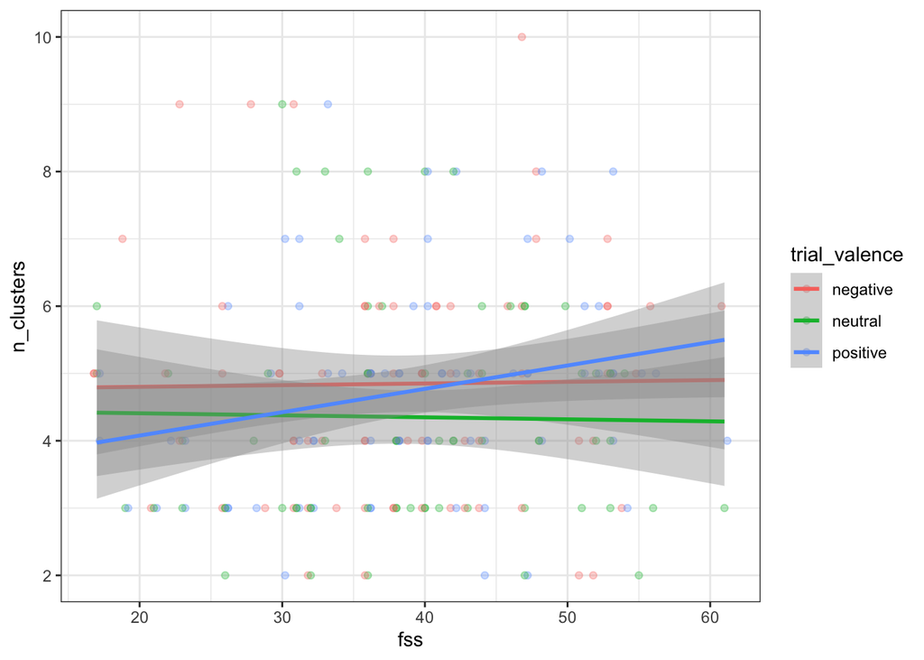

```r
dat <- df_survey %>%
  select(pid, matches("^fss(.*[^0-9]$|$)"), -matches("timer")) %>%
  inner_join(df_graphs)
dat %>%
  ggplot(aes(x = fss, y = n_clusters, color = trial_valence)) +
  geom_point(alpha = .3, position = position_dodge(.6)) +
  geom_smooth(method="lm")
```

```r
dat %>%
  filter(trial_valence == "negative" ) %>%
  mutate_if(is.numeric, scale) %>%
  lm(n_clusters ~ fss, . ) %>%
  summary
```

```
##
## Call:
## lm(formula = n_clusters ~ fss, data = .)
##
## Residuals:
##      Min       1Q   Median       3Q      Max
## -1.62430 -1.01871  0.07989  0.64094  2.89354
##
## Coefficients:
##              Estimate Std. Error t value Pr(>|t|)
## (Intercept) 4.901e-17  1.187e-01   0.000    1.000
## fss         1.414e-02  1.195e-01   0.118    0.906
##
## Residual standard error: 1.007 on 70 degrees of freedom
## Multiple R-squared:  0.0002001,  Adjusted R-squared:  -0.01408
## F-statistic: 0.01401 on 1 and 70 DF,  p-value: 0.9061
```

```r
dat %>%
  filter(trial_valence == "positive" ) %>%
  mutate_if(is.numeric, scale) %>%
  lm(n_clusters ~ fss, . ) %>%
  summary
```

```
##
## Call:
## lm(formula = n_clusters ~ fss, data = .)
##
## Residuals:
##      Min       1Q   Median       3Q      Max
## -1.97015 -0.68138 -0.09995  0.30834  2.92291
##
## Coefficients:
##              Estimate Std. Error t value Pr(>|t|)
## (Intercept) 2.170e-16  1.147e-01   0.000   1.0000
## fss         2.291e-01  1.155e-01   1.984   0.0512 .
## ---
## Signif. codes:  0 '***' 0.001 '**' 0.01 '*' 0.05 '.' 0.1 ' ' 1
##
## Residual standard error: 0.9802 on 71 degrees of freedom
## Multiple R-squared:  0.05251,    Adjusted R-squared:  0.03916
## F-statistic: 3.934 on 1 and 71 DF,  p-value: 0.05117
```

```r
dat %>%
  filter(trial_valence == "negative" | trial_valence == "neutral") %>%
  mutate_if(is.numeric, scale) %>%
  lm(n_clusters ~ fss*trial_valence, . ) %>%
  summary
```

```
##
## Call:
## lm(formula = n_clusters ~ fss * trial_valence, data = .)
##
## Residuals:
##     Min      1Q  Median      3Q     Max
## -1.6626 -0.7817 -0.1874  0.6446  2.9618
##
## Coefficients:
##                          Estimate Std. Error t value Pr(>|t|)
## (Intercept)               0.14206    0.11788   1.205   0.2302
## fss                       0.01451    0.11899   0.122   0.9031
## trial_valenceneutral     -0.28572    0.16729  -1.708   0.0899 .
## fss:trial_valenceneutral -0.03190    0.16788  -0.190   0.8496
## ---
## Signif. codes:  0 '***' 0.001 '**' 0.01 '*' 0.05 '.' 0.1 ' ' 1
##
## Residual standard error: 1 on 139 degrees of freedom
## Multiple R-squared:  0.02081,    Adjusted R-squared:  -0.0003197
## F-statistic: 0.9849 on 3 and 139 DF,  p-value: 0.4019
```

# 10 Is alx related to psychopathology controlling for n clusters?

```r
dat <- df_survey %>%
  select(pid, matches("^paq(.*[^0-9]$|$)"), phq, gad, -matches("timer")) %>%
  inner_join(df_graphs)
cor.test(df_survey$paq, df_survey$phq)
```

```
##
##  Pearson's product-moment correlation
##
## data:  df_survey$paq and df_survey$phq
## t = 3.8024, df = 90, p-value = 0.0002605
## alternative hypothesis: true correlation is not equal to 0
## 95 percent confidence interval:
##  0.1810139 0.5360115
## sample estimates:
##       cor
## 0.3720381
```

```r
cor.test(df_survey$paq_dif, df_survey$phq)
```

```
##
##  Pearson's product-moment correlation
##
## data:  df_survey$paq_dif and df_survey$phq
## t = 3.5503, df = 90, p-value = 0.0006144
## alternative hypothesis: true correlation is not equal to 0
## 95 percent confidence interval:
##  0.1569443 0.5181181
## sample estimates:
##      cor
## 0.350495
```

```r
cor.test(df_survey$paq_ddf, df_survey$phq)
```

```
##
##  Pearson's product-moment correlation
##
## data:  df_survey$paq_ddf and df_survey$phq
## t = 3.6648, df = 90, p-value = 0.0004181
## alternative hypothesis: true correlation is not equal to 0
## 95 percent confidence interval:
##  0.1679258 0.5263211
## sample estimates:
##       cor
## 0.3603493
```

```r
cor.test(df_survey$paq_eot, df_survey$phq)
```

```
##
##  Pearson's product-moment correlation
##
## data:  df_survey$paq_eot and df_survey$phq
## t = 2.3876, df = 90, p-value = 0.01905
## alternative hypothesis: true correlation is not equal to 0
## 95 percent confidence interval:
##  0.04131348 0.42751221
## sample estimates:
##       cor
## 0.2440657
```

```r
cor.test(df_survey$paq, df_survey$gad)
```

```
##
##  Pearson's product-moment correlation
##
## data:  df_survey$paq and df_survey$gad
## t = 1.9415, df = 90, p-value = 0.05532
## alternative hypothesis: true correlation is not equal to 0
## 95 percent confidence interval:
##  -0.004503074  0.389328591
## sample estimates:
##       cor
## 0.2004993
```

```r
cor.test(df_survey$paq_dif, df_survey$gad)
```

```
##
##  Pearson's product-moment correlation
##
## data:  df_survey$paq_dif and df_survey$gad
## t = 3.1101, df = 90, p-value = 0.002505
## alternative hypothesis: true correlation is not equal to 0
## 95 percent confidence interval:
##  0.1139728 0.4853671
## sample estimates:
##       cor
## 0.3115182
```

```r
cor.test(df_survey$paq_ddf, df_survey$gad)
```

```
##
##  Pearson's product-moment correlation
##
## data:  df_survey$paq_ddf and df_survey$gad
## t = 2.1622, df = 90, p-value = 0.03326
## alternative hypothesis: true correlation is not equal to 0
## 95 percent confidence interval:
##  0.01822739 0.40844292
## sample estimates:
##       cor
## 0.2222152
```

```r
cor.test(df_survey$paq_eot, df_survey$gad)
```

```
##
##  Pearson's product-moment correlation
##
## data:  df_survey$paq_eot and df_survey$gad
## t = 0.11135, df = 90, p-value = 0.9116
## alternative hypothesis: true correlation is not equal to 0
## 95 percent confidence interval:
##  -0.1935465  0.2160343
## sample estimates:
##        cor
## 0.01173618
```

```r
dat %>%
  filter(trial_valence == "negative") %>%
  mutate_if(is.numeric, scale) %>%
  lm(phq ~ n_clusters, .) %>%
  summary
```

```
##
## Call:
## lm(formula = phq ~ n_clusters, data = .)
##
## Residuals:
##     Min      1Q  Median      3Q     Max
## -1.5519 -0.6676 -0.0821  0.6332  2.3020
##
## Coefficients:
##               Estimate Std. Error t value Pr(>|t|)
## (Intercept)  1.346e-16  1.184e-01   0.000    1.000
## n_clusters  -7.112e-02  1.192e-01  -0.597    0.553
##
## Residual standard error: 1.005 on 70 degrees of freedom
## Multiple R-squared:  0.005058,   Adjusted R-squared:  -0.009156
## F-statistic: 0.3558 on 1 and 70 DF,  p-value: 0.5528
```

```r
dat %>%
  filter(trial_valence == "negative") %>%
  mutate_if(is.numeric, scale) %>%
  lm(phq ~ paq, .) %>%
  summary
```

```
##
## Call:
## lm(formula = phq ~ paq, data = .)
##
## Residuals:
##      Min       1Q   Median       3Q      Max
## -2.22302 -0.60569 -0.06125  0.52311  2.14270
##
## Coefficients:
##              Estimate Std. Error t value Pr(>|t|)
## (Intercept) 2.016e-16  1.095e-01   0.000 1.000000
## paq         3.861e-01  1.103e-01   3.502 0.000808 ***
## ---
## Signif. codes:  0 '***' 0.001 '**' 0.01 '*' 0.05 '.' 0.1 ' ' 1
##
## Residual standard error: 0.929 on 70 degrees of freedom
## Multiple R-squared:  0.1491, Adjusted R-squared:  0.137
## F-statistic: 12.27 on 1 and 70 DF,  p-value: 0.0008076
```

```r
dat %>%
  filter(trial_valence == "negative") %>%
  mutate_if(is.numeric, scale) %>%
  lm(phq ~ n_clusters + paq, .) %>%
  summary
```

```
##
## Call:
## lm(formula = phq ~ n_clusters + paq, data = .)
##
## Residuals:
##     Min      1Q  Median      3Q     Max
## -2.2229 -0.6365 -0.0330  0.5245  2.0718
##
## Coefficients:
##              Estimate Std. Error t value Pr(>|t|)
## (Intercept) 2.014e-16  1.102e-01   0.000  1.00000
## n_clusters  2.466e-02  1.145e-01   0.215  0.83006
## paq         3.922e-01  1.145e-01   3.426  0.00104 **
## ---
## Signif. codes:  0 '***' 0.001 '**' 0.01 '*' 0.05 '.' 0.1 ' ' 1
##
## Residual standard error: 0.9354 on 69 degrees of freedom
## Multiple R-squared:  0.1497, Adjusted R-squared:  0.125
## F-statistic: 6.073 on 2 and 69 DF,  p-value: 0.00372
```

# 11 Explanations of why they chose what they did

TODO

# 12 More TODOs

- Explore differences in degree related metrics
  - mean degree per person
  - can I do some kind of clustering of degree distributions to identify classsification schemas?
    - [Degree distribution wikipedia](https://en.wikipedia.org/wiki/Degree_distribution)
    - [clustering pr distributions](https://stats.stackexchange.com/questions/13186/clustering-probability-distributions-methods-metrics)